# How to plot a histogram with python

Bảng sau là kết quả khảo sát lượng thuốc hút trung bình mỗi ngày của 68 người có hút thuốc

| Số điếu thuốc hút trung bình một ngày | [0;8) | [8;12) | [12;16) | [16;24) | [24;28) | [28;34) | [34; 50] |
| --- | --- | --- | --- | --- | --- | --- | --- |
| Số lượng | 4 | 6 | 12 | 28 | 8 | 6 | 4 |

1. Lập bảng cho thấy tần số (frequency), tần suất (relative frequency), mật độ (density), tần số tích lũy (cumulative frequency), tần suất tích lũy (cumulative relative frequency).
2. Vẽ biểu đồ histogram.
3. Vẽ biểu đồ tần suất tích lũy.
4. Nhận xét.

**Bài làm**

**1. Lập bảng cho thấy tần số (frequency), tần suất (relative frequency), mật độ (density), tần số tích lũy (cumulative frequency), tần suất tích lũy (cumulative relative frequency).**

```python
import matplotlib.pyplot as plt
import pandas as pd
import numpy as np
import math

# Các khoảng
intervals = np.array([0, 8, 12, 16, 24, 28, 34, 50])

# Số các khoảng
num_of_intervals = len(intervals)-1

# Độ lớn của các khoảng
intervals_width = np.diff(intervals)

# Tần số của các khoảng
frequency = np.array([4, 6, 12, 28, 8, 6, 4])

# Tần suất của các khoảng
probability = np.round(frequency/np.sum(frequency), 3)

# Mật độ
density = np.round(np.array(probability/intervals_width), 3)

# Tần số tích lũy
cumsum = np.cumsum(frequency)

# Tần suất tích lũy
cumsum_prob = np.round(np.cumsum(probability), 3)


pd.DataFrame({
    "Interval":["{} - {}" .format(intervals[i], intervals[i+1]) for i in range(num_of_intervals)],
    "Frequency" : frequency,
    "Density" : density,
    "Relative Frequency": probability,
    "Cumulative Frequency": cumsum,
    "Cumulative relative frequency": cumsum_prob
})
```

|  | Interval | Frequency | Density | Relative Frequency | Cumulative Frequency | Cumulative relative frequency |
| --- | --- | --- | --- | --- | --- | --- |
| 0 | 0 - 8 | 4 | 0.007 | 0.059 | 4 | 0.059 |
| 1 | 8 - 12 | 6 | 0.022 | 0.088 | 10 | 0.147 |
| 2 | 12 - 16 | 12 | 0.044 | 0.176 | 22 | 0.323 |
| 3 | 16 - 24 | 28 | 0.052 | 0.412 | 50 | 0.735 |
| 4 | 24 - 28 | 8 | 0.030 | 0.118 | 58 | 0.853 |
| 5 | 28 - 34 | 6 | 0.015 | 0.088 | 64 | 0.941 |
| 6 | 34 - 50 | 4 | 0.004 | 0.059 | 68 | 1.000 |

**2. Vẽ biểu đồ histogram.**

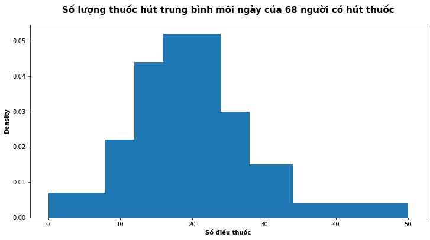

```python
fig, ax = plt.subplots(figsize=(12, 6))

# Cận dưới của các khoảng
sub_intervals = intervals[:-1]

# Do ta đã có được bảng tần số, nên để vẽ histogram ta sẽ dùng biểu đồ thanh với kích thước các khoảng bằng intervals_width, chiều cao theo density.
ax.bar(sub_intervals, density, intervals_width, align = 'edge')

ax.set_xlabel("Số điếu thuốc", fontweight = 'bold')
ax.set_ylabel("Density", fontweight = 'bold')
ax.set_title(
    "Số lượng thuốc hút trung bình mỗi ngày của 68 người có hút thuốc",
    fontsize = 15,
    fontweight = 'bold',
    pad = 20,
    loc = 'center')
plt.show()
```

**3. Vẽ biểu đồ tần suất tích lũy.**

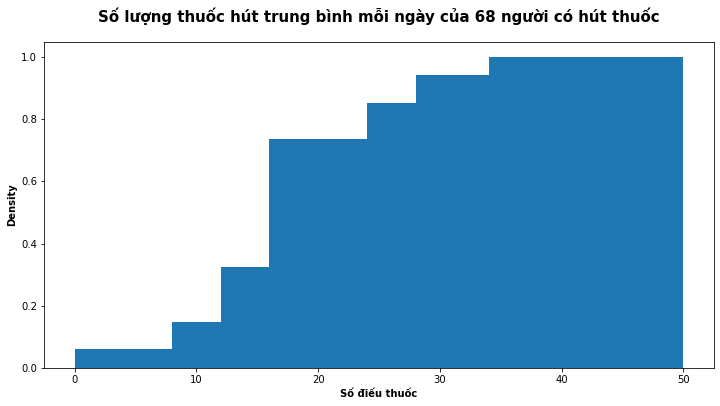

```python
fig, ax = plt.subplots(figsize=(12, 6))

# Biểu đồ tần suất tích lữy
ax.bar(sub_intervals, cumsum_prob, intervals_width, align = 'edge')

ax.set_xlabel("Số điếu thuốc", fontweight = 'bold')
ax.set_ylabel("Density", fontweight = 'bold')
ax.set_title(
    "Số lượng thuốc hút trung bình mỗi ngày của 68 người có hút thuốc",
    fontsize = 15,
    fontweight = 'bold',
    pad = 20,
    loc = 'center')

plt.show()
```